# BeachBoys BikeShare

### Import Libraries

```python
import pandas as pd
import numpy as np
from scipy.stats import norm
from scipy import stats
```

```python
import matplotlib.pyplot as plt
import seaborn as sns
import warnings
warnings.filterwarnings('ignore')
%matplotlib inline
```

```python
from sklearn import preprocessing
from sklearn.preprocessing import OneHotEncoder
from sklearn.model_selection import StratifiedShuffleSplit
from sklearn.model_selection import train_test_split
from sklearn.linear_model import LinearRegression
from sklearn.metrics import mean_squared_error
from sklearn.ensemble import GradientBoostingRegressor
```

```python
pd.set_option('display.max_columns', 100)
pd.set_option('display.max_rows', 100)
pd.options.display.max_rows = 100
```

```python
# Functions
def OneHotEncoder(df, colList):
    c2 = []
    for c in colList:
        if df[c].nunique()>2 :
            c2.append(c)
    df = pd.get_dummies(df,columns=c2,drop_first=True)
    return df
```

### Read Data

```python
station_data = pd.read_csv('data/station_data.csv')
weather_data = pd.read_csv('data/weather_data.csv')
trip_data = pd.read_csv('data/trip_data.csv')
```

```python
station_data.shape
```

```
(76, 6)
```

```python
station_data.head()
```

|  | Id | Name | Lat | Long | Dock Count | City |
| --- | --- | --- | --- | --- | --- | --- |
| 0 | 2 | San Jose Diridon Caltrain Station | 37.329732 | -121.901782 | 27 | San Jose |
| 1 | 3 | San Jose Civic Center | 37.330698 | -121.888979 | 15 | San Jose |
| 2 | 4 | Santa Clara at Almaden | 37.333988 | -121.894902 | 11 | San Jose |
| 3 | 5 | Adobe on Almaden | 37.331415 | -121.893200 | 19 | San Jose |
| 4 | 6 | San Pedro Square | 37.336721 | -121.894074 | 15 | San Jose |

```python
weather_data.head()
```

|  | Date | Max TemperatureF | Mean TemperatureF | Min TemperatureF | Max Dew PointF | MeanDew PointF | Min DewpointF | Max Humidity | Mean Humidity | Min Humidity | Max Sea Level PressureIn | Mean Sea Level PressureIn | Min Sea Level PressureIn | Max VisibilityMiles | Mean VisibilityMiles | Min VisibilityMiles | Max Wind SpeedMPH | Mean Wind SpeedMPH | Max Gust SpeedMPH | PrecipitationIn | CloudCover | Events | WindDirDegrees | Zip |
| --- | --- | --- | --- | --- | --- | --- | --- | --- | --- | --- | --- | --- | --- | --- | --- | --- | --- | --- | --- | --- | --- | --- | --- | --- |
| 0 | 01/09/2014 | 83.0 | 70.0 | 57.0 | 58.0 | 56.0 | 52.0 | 86.0 | 64.0 | 42.0 | 29.86 | 29.82 | 29.76 | 10.0 | 10.0 | 8.0 | 16.0 | 7.0 | 20.0 | 0.0 | 0.0 | NaN | 290.0 | 94107 |
| 1 | 02/09/2014 | 72.0 | 66.0 | 60.0 | 58.0 | 57.0 | 55.0 | 84.0 | 73.0 | 61.0 | 29.87 | 29.82 | 29.79 | 10.0 | 10.0 | 7.0 | 21.0 | 8.0 | NaN | 0.0 | 5.0 | NaN | 290.0 | 94107 |
| 2 | 03/09/2014 | 76.0 | 69.0 | 61.0 | 57.0 | 56.0 | 55.0 | 84.0 | 69.0 | 53.0 | 29.81 | 29.76 | 29.72 | 10.0 | 10.0 | 10.0 | 21.0 | 8.0 | 24.0 | 0.0 | 4.0 | NaN | 276.0 | 94107 |
| 3 | 04/09/2014 | 74.0 | 68.0 | 61.0 | 57.0 | 57.0 | 56.0 | 84.0 | 71.0 | 57.0 | 29.81 | 29.76 | 29.72 | 10.0 | 10.0 | 8.0 | 22.0 | 8.0 | 25.0 | 0.0 | 5.0 | NaN | 301.0 | 94107 |
| 4 | 05/09/2014 | 72.0 | 66.0 | 60.0 | 57.0 | 56.0 | 54.0 | 84.0 | 71.0 | 57.0 | 29.92 | 29.87 | 29.81 | 10.0 | 9.0 | 7.0 | 18.0 | 8.0 | 32.0 | 0.0 | 4.0 | NaN | 309.0 | 94107 |

```python
trip_data.head()
```

|  | Trip ID | Start Date | Start Station | End Date | End Station | Subscriber Type |
| --- | --- | --- | --- | --- | --- | --- |
| 0 | 913460 | 31/08/2015 23:26 | 50 | 31/08/2015 23:39 | 70 | Subscriber |
| 1 | 913459 | 31/08/2015 23:11 | 31 | 31/08/2015 23:28 | 27 | Subscriber |
| 2 | 913455 | 31/08/2015 23:13 | 47 | 31/08/2015 23:18 | 64 | Subscriber |
| 3 | 913454 | 31/08/2015 23:10 | 10 | 31/08/2015 23:17 | 8 | Subscriber |
| 4 | 913453 | 31/08/2015 23:09 | 51 | 31/08/2015 23:22 | 60 | Customer |

### Initial Exploration

```python
station_data.describe()
```

|  | Id | Lat | Long | Dock Count |
| --- | --- | --- | --- | --- |
| count | 76.000000 | 76.000000 | 76.000000 | 76.000000 |
| mean | 46.513158 | 37.597618 | -122.228385 | 17.815789 |
| std | 26.142427 | 0.200675 | 0.205135 | 4.015671 |
| min | 2.000000 | 37.329732 | -122.418954 | 11.000000 |
| 25% | 25.750000 | 37.393338 | -122.400824 | 15.000000 |
| 50% | 47.500000 | 37.772936 | -122.389138 | 15.000000 |
| 75% | 68.250000 | 37.787475 | -122.083233 | 19.000000 |
| max | 90.000000 | 37.804770 | -121.877349 | 27.000000 |

```python
trip_data.describe()
```

|  | Trip ID | Start Station | End Station |
| --- | --- | --- | --- |
| count | 354152.000000 | 354152.000000 | 354152.000000 |
| mean | 676962.274416 | 59.755159 | 59.714665 |
| std | 138874.153513 | 17.891604 | 18.034273 |
| min | 432947.000000 | 2.000000 | 2.000000 |
| 25% | 557009.750000 | 51.000000 | 50.000000 |
| 50% | 679451.500000 | 63.000000 | 63.000000 |
| 75% | 798026.250000 | 71.000000 | 70.000000 |
| max | 913460.000000 | 90.000000 | 90.000000 |

### Data Cleaning

- Fix the station renameing before starting the analysis
- Check whether the data is duplicated, check sample of the stations

```python
station_data[station_data['Id'] == 89]
```

|  | Id | Name | Lat | Long | Dock Count | City |
| --- | --- | --- | --- | --- | --- | --- |
| 65 | 89 | Civic Center BART (7th at Market) | 37.780353 | -122.41226 | 23 | San Francisco |

```python
station_data[station_data['Id'] == 90]
```

|  | Id | Name | Lat | Long | Dock Count | City |
| --- | --- | --- | --- | --- | --- | --- |
| 66 | 90 | Civic Center BART (7th at Market) | 37.781039 | -122.411748 | 23 | San Francisco |

- Data is duplicated for the station with name change, change the id, drop the duplicated values

```python
station_rename = {23:85, 25:86, 49:87,69:88,72:90,89:90}
#Fix the station and trip Data
for key, value in station_rename.items():
    trip_data.loc[trip_data['Start Station']==key , 'Start Station'] =value
    trip_data.loc[trip_data['End Station']==key , 'End Station'] =value
    station_data.loc[station_data['Id']==key , 'Id'] =value
```

```python
# sorting by first name
station_data.sort_values("Id", inplace=True)
```

```python
# dropping duplicate values from Station Data
station_data.drop_duplicates(subset='Id',keep="last",inplace=True)
```

```python
# Check Null
df_nan = pd.DataFrame({'Null Count': trip_data.isnull().sum(),
                        'Null %':trip_data.isna().mean().round(4) * 100},
                      columns=['Null Count' , 'Null %'])
print(df_nan[df_nan['Null Count'] > 0])
```

```
Empty DataFrame
Columns: [Null Count, Null %]
Index: []
```

- No Null values Available, great!
- Update column Data Types

```python
trip_data['Start Date']=pd.to_datetime(trip_data ['Start Date'],infer_datetime_format=True)
trip_data['End Date']=pd.to_datetime(trip_data ['End Date'],infer_datetime_format=True)
```

```python
#Convert Weather Date
weather_data.Date = pd.to_datetime(weather_data.Date, format='%d/%m/%Y')
```

### Feature Engineering

- Extract features to help in EDA and model building

```python
trip_data.columns
```

```
Index(['Trip ID', 'Start Date', 'Start Station', 'End Date', 'End Station',
       'Subscriber Type'],
      dtype='object')
```

```python
trip_data.head()
```

|  | Trip ID | Start Date | Start Station | End Date | End Station | Subscriber Type |
| --- | --- | --- | --- | --- | --- | --- |
| 0 | 913460 | 2015-08-31 23:26:00 | 50 | 2015-08-31 23:39:00 | 70 | Subscriber |
| 1 | 913459 | 2015-08-31 23:11:00 | 31 | 2015-08-31 23:28:00 | 27 | Subscriber |
| 2 | 913455 | 2015-08-31 23:13:00 | 47 | 2015-08-31 23:18:00 | 64 | Subscriber |
| 3 | 913454 | 2015-08-31 23:10:00 | 10 | 2015-08-31 23:17:00 | 8 | Subscriber |
| 4 | 913453 | 2015-08-31 23:09:00 | 51 | 2015-08-31 23:22:00 | 60 | Customer |

```python
# Create Duration Column in Trp
trip_data['duration'] = (trip_data['End Date'] - trip_data['Start Date']).astype('timedelta64[m]')
```

```python
# Extract Trip date from Start Date to link with Weather Data
trip_data['date'] = trip_data['Start Date'].dt.date
```

```python
trip_data['year'] =  pd.DatetimeIndex(trip_data['date']).year
```

```python
trip_data['month'] =  pd.DatetimeIndex(trip_data['date']).month
```

```python
trip_data['day'] =  pd.DatetimeIndex(trip_data['date']).day
```

```python
trip_data['month_year'] =pd.to_datetime(trip_data['date']).dt.to_period('M')
```

```python
trip_data['hour'] =pd.to_datetime(trip_data['Start Date']).dt.hour
```

```python
trip_data['weekday'] =pd.to_datetime(trip_data['Start Date']).dt.weekday
```

```python
weather_data.rename(columns={"Date": "date"} , inplace =True)
```

```python
weather_data['year'] =  pd.DatetimeIndex(weather_data['date']).year
weather_data['month'] =  pd.DatetimeIndex(weather_data['date']).month
weather_data['day'] =  pd.DatetimeIndex(weather_data['date']).day
```

## Exploratory Data Analysis

```python
station_data.columns
```

```
Index(['Id', 'Name', 'Lat', 'Long', 'Dock Count', 'City'], dtype='object')
```

```python
trip_data[trip_data['duration']>10000]
```

[output not shown]

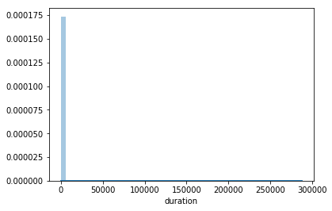

```python
# Check Duration Distribution
sns.distplot(trip_data['duration'])
```

- Some trips has more than 100 minutes duration. need investigation as an outliar

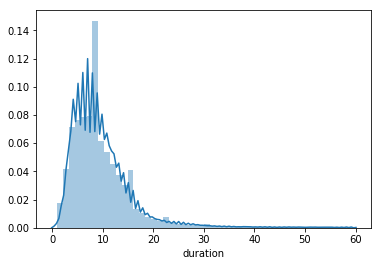

```python
# Exclude it for now to check the distribution   (1 hour limit)
sns.distplot(trip_data[trip_data['duration'] < 60]['duration'])
```

- Subscriber Type: Customer VS Subscriber Data
- The distrubtion is right skewed, most of the trips are between 1 miutes and 10-15 minutes

```python
trip_data.columns
```

[output not shown]

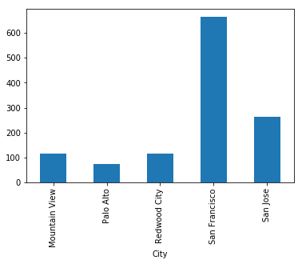

```python
# Station City Analysis
station_data.groupby('City')['Dock Count'].sum().plot(kind='bar')
plt.show()
```

- San Francisco City has the largest number of Bike Docks

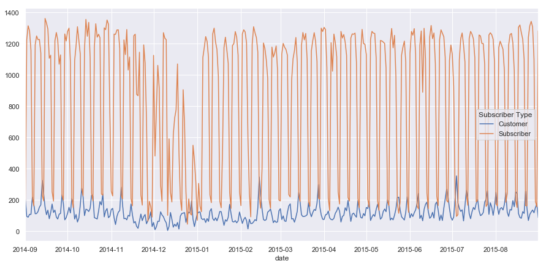

```python
# Trip Daily Trend by Subscriber Type
fig, ax = plt.subplots(figsize=(15,7))
trip_data.groupby(['date','Subscriber Type']).count()['Trip ID'].unstack().plot(ax=ax)
```

- Subscriber Type " Subscriber" has the majority of the trips in the platform. Customers are mostly visitors to the city

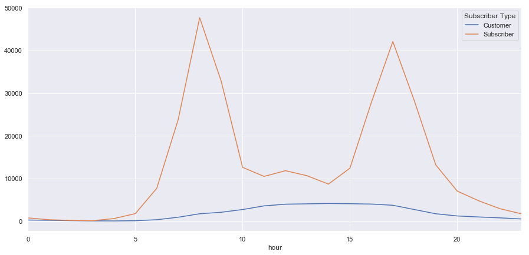

```python
# Trip houry rate by Subscriber Type
fig, ax = plt.subplots(figsize=(15,7))
trip_data.groupby(['hour','Subscriber Type']).count()['Trip ID'].unstack().plot(ax=ax)
```

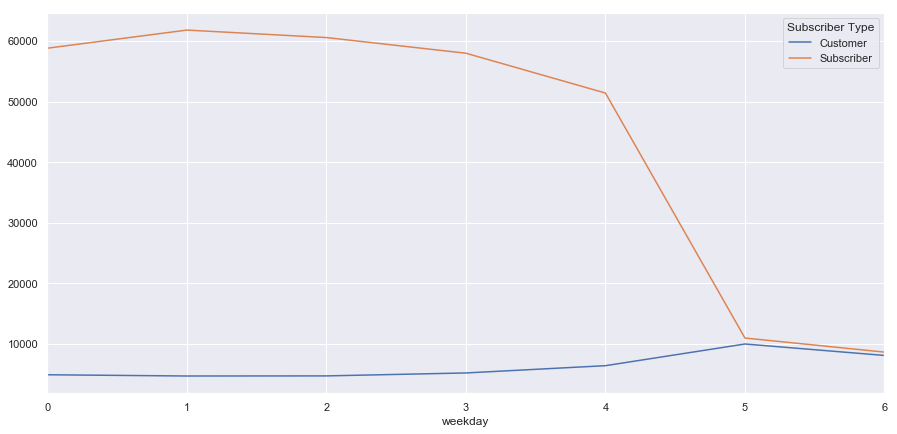

```python
# Trip weekday rate by Subscriber Type, 0 is Monday and 6 is Sunday.
fig, ax = plt.subplots(figsize=(15,7))
trip_data.groupby(['weekday','Subscriber Type']).count()['Trip ID'].unstack().plot(ax=ax)
```

- Most of the trips are on the normal weekdays, and very less during weekends